# BankMarketing caret v4 Balanced data

# Both - Combination of Under & Over sampling

# options & settings

CSS for scrollable output & Header colors

chunk options

Turning scientific / Exponential numbers off

```r
options(scipen = 999)
```

## Source

https://www.machinelearningplus.com/machine-learning/caret-package/

https://youtu.be/mf1A_8K84rw

## Loading libs

```r
library(tidyverse)
library(ggthemes)
library(caret)
library(caretEnsemble)
library(ROSE)
```

```r
library(skimr)
library(naniar) # to plot missing values
library(scales)
library(glue)
library(patchwork)
library(GGally)
```

## Creating & setting custom theme

```r
theme_viny_bright <- function(){

  library(ggthemes)

  ggthemes::theme_fivethirtyeight() %+replace%

  theme(
    axis.title = element_text(),
    axis.text = element_text(size = 8),
    legend.text = element_text(size = 10),
    panel.background = element_rect(fill = "white"),
    plot.background = element_rect(fill = "white"),
    strip.background = element_blank(),
    legend.background = element_rect(fill = NA),
    legend.key = element_rect(fill = NA),
    plot.title = element_text(hjust = 0.5,
                              size = 19,
                              face = "bold"),
    plot.subtitle = element_text(hjust = 0.5)
      )

  }

theme_set(theme_viny_bright())
```

# Loading data

```r
data <- read.csv("bank-additional.csv", header = TRUE, sep = ";")

head(data)
```

|  | age | job | marital | education | default | housing | loan | contact | month | day_of_week | duration | campaign | pdays | previous | poutcome | emp.var.rate | cons.price.idx | cons.conf.idx | euribor3m | nr.employed | y |
| --- | --- | --- | --- | --- | --- | --- | --- | --- | --- | --- | --- | --- | --- | --- | --- | --- | --- | --- | --- | --- | --- |
| 1 | 30 | blue-collar | married | basic.9y | no | yes | no | cellular | may | fri | 487 | 2 | 999 | 0 | nonexistent | -1.8 | 92.893 | -46.2 | 1.313 | 5099.1 | no |
| 2 | 39 | services | single | high.school | no | no | no | telephone | may | fri | 346 | 4 | 999 | 0 | nonexistent | 1.1 | 93.994 | -36.4 | 4.855 | 5191.0 | no |
| 3 | 25 | services | married | high.school | no | yes | no | telephone | jun | wed | 227 | 1 | 999 | 0 | nonexistent | 1.4 | 94.465 | -41.8 | 4.962 | 5228.1 | no |
| 4 | 38 | services | married | basic.9y | no | unknown | unknown | telephone | jun | fri | 17 | 3 | 999 | 0 | nonexistent | 1.4 | 94.465 | -41.8 | 4.959 | 5228.1 | no |
| 5 | 47 | admin. | married | university.degree | no | yes | no | cellular | nov | mon | 58 | 1 | 999 | 0 | nonexistent | -0.1 | 93.200 | -42.0 | 4.191 | 5195.8 | no |
| 6 | 32 | services | single | university.degree | no | no | no | cellular | sep | thu | 128 | 3 | 999 | 2 | failure | -1.1 | 94.199 | -37.5 | 0.884 | 4963.6 | no |

# Exploring data

```r
str(data)
```

```
'data.frame':   4119 obs. of  21 variables:
 $ age           : int  30 39 25 38 47 32 32 41 31 35 ...
 $ job           : chr  "blue-collar" "services" "services" "services" ...
 $ marital       : chr  "married" "single" "married" "married" ...
 $ education     : chr  "basic.9y" "high.school" "high.school" "basic.9y" ...
 $ default       : chr  "no" "no" "no" "no" ...
 $ housing       : chr  "yes" "no" "yes" "unknown" ...
 $ loan          : chr  "no" "no" "no" "unknown" ...
 $ contact       : chr  "cellular" "telephone" "telephone" "telephone" ...
 $ month         : chr  "may" "may" "jun" "jun" ...
 $ day_of_week   : chr  "fri" "fri" "wed" "fri" ...
 $ duration      : int  487 346 227 17 58 128 290 44 68 170 ...
 $ campaign      : int  2 4 1 3 1 3 4 2 1 1 ...
 $ pdays         : int  999 999 999 999 999 999 999 999 999 999 ...
 $ previous      : int  0 0 0 0 0 2 0 0 1 0 ...
 $ poutcome      : chr  "nonexistent" "nonexistent" "nonexistent" "nonexistent" ...
 $ emp.var.rate  : num  -1.8 1.1 1.4 1.4 -0.1 -1.1 -1.1 -0.1 -0.1 1.1 ...
 $ cons.price.idx: num  92.9 94 94.5 94.5 93.2 ...
 $ cons.conf.idx : num  -46.2 -36.4 -41.8 -41.8 -42 -37.5 -37.5 -42 -42 -36.4 ...
 $ euribor3m     : num  1.31 4.86 4.96 4.96 4.19 ...
 $ nr.employed   : num  5099 5191 5228 5228 5196 ...
 $ y             : chr  "no" "no" "no" "no" ...
```

also setting months levels correctly so that it can be sorted by calender order of month

```r
data <- data %>%
    mutate(across(is.character, factor),
           month = str_to_title(month), # this will correct text style to month.abbr
           month = factor(month, levels = month.abb), # this will sort the months
           month = factor(month))  # this will drop two unused levels - Jan, Feb

str(data)
```

```
'data.frame':   4119 obs. of  21 variables:
 $ age           : int  30 39 25 38 47 32 32 41 31 35 ...
 $ job           : Factor w/ 12 levels "admin.","blue-collar",..: 2 8 8 8 1 8 1 3 8 2 ...
 $ marital       : Factor w/ 4 levels "divorced","married",..: 2 3 2 2 2 3 3 2 1 2 ...
 $ education     : Factor w/ 8 levels "basic.4y","basic.6y",..: 3 4 4 3 7 7 7 7 6 3 ...
 $ default       : Factor w/ 3 levels "no","unknown",..: 1 1 1 1 1 1 1 2 1 2 ...
 $ housing       : Factor w/ 3 levels "no","unknown",..: 3 1 3 2 3 1 3 3 1 1 ...
 $ loan          : Factor w/ 3 levels "no","unknown",..: 1 1 1 2 1 1 1 1 1 1 ...
 $ contact       : Factor w/ 2 levels "cellular","telephone": 1 2 2 2 1 1 1 1 1 2 ...
 $ month         : Factor w/ 10 levels "Mar","Apr","May",..: 3 3 4 4 9 7 7 9 9 3 ...
 $ day_of_week   : Factor w/ 5 levels "fri","mon","thu",..: 1 1 5 1 2 3 2 2 4 3 ...
 $ duration      : int  487 346 227 17 58 128 290 44 68 170 ...
 $ campaign      : int  2 4 1 3 1 3 4 2 1 1 ...
 $ pdays         : int  999 999 999 999 999 999 999 999 999 999 ...
 $ previous      : int  0 0 0 0 0 2 0 0 1 0 ...
 $ poutcome      : Factor w/ 3 levels "failure","nonexistent",..: 2 2 2 2 2 1 2 2 1 2 ...
 $ emp.var.rate  : num  -1.8 1.1 1.4 1.4 -0.1 -1.1 -1.1 -0.1 -0.1 1.1 ...
 $ cons.price.idx: num  92.9 94 94.5 94.5 93.2 ...
 $ cons.conf.idx : num  -46.2 -36.4 -41.8 -41.8 -42 -37.5 -37.5 -42 -42 -36.4 ...
 $ euribor3m     : num  1.31 4.86 4.96 4.96 4.19 ...
 $ nr.employed   : num  5099 5191 5228 5228 5196 ...
 $ y             : Factor w/ 2 levels "no","yes": 1 1 1 1 1 1 1 1 1 1 ...
```

find missing values

```r
sapply(data, function(x) sum(is.na(x)))
```

```
           age            job        marital      education        default        housing
             0              0              0              0              0              0
          loan        contact          month    day_of_week       duration       campaign
             0              0              0              0              0              0
         pdays       previous       poutcome   emp.var.rate cons.price.idx  cons.conf.idx
             0              0              0              0              0              0
     euribor3m    nr.employed              y
             0              0              0
```

```r
summary(data)
```

```
      age                 job           marital                   education       default
 Min.   :18.00   admin.     :1012   divorced: 446   university.degree  :1264   no     :3315
 1st Qu.:32.00   blue-collar: 884   married :2509   high.school        : 921   unknown: 803
 Median :38.00   technician : 691   single  :1153   basic.9y           : 574   yes    :   1
 Mean   :40.11   services   : 393   unknown :  11   professional.course: 535
 3rd Qu.:47.00   management : 324                   basic.4y           : 429
 Max.   :88.00   retired    : 166                   basic.6y           : 228
                 (Other)    : 649                   (Other)            : 168
    housing          loan           contact         month      day_of_week    duration
 no     :1839   no     :3349   cellular :2652   May    :1378   fri:768     Min.   :   0.0
 unknown: 105   unknown: 105   telephone:1467   Jul    : 711   mon:855     1st Qu.: 103.0
 yes    :2175   yes    : 665                    Aug    : 636   thu:860     Median : 181.0
                                                Jun    : 530   tue:841     Mean   : 256.8
                                                Nov    : 446   wed:795     3rd Qu.: 317.0
                                                Apr    : 215               Max.   :3643.0
                                                (Other): 203
    campaign          pdays          previous             poutcome     emp.var.rate
 Min.   : 1.000   Min.   :  0.0   Min.   :0.0000   failure    : 454   Min.   :-3.40000
 1st Qu.: 1.000   1st Qu.:999.0   1st Qu.:0.0000   nonexistent:3523   1st Qu.:-1.80000
 Median : 2.000   Median :999.0   Median :0.0000   success    : 142   Median : 1.10000
 Mean   : 2.537   Mean   :960.4   Mean   :0.1903                      Mean   : 0.08497
 3rd Qu.: 3.000   3rd Qu.:999.0   3rd Qu.:0.0000                      3rd Qu.: 1.40000
 Max.   :35.000   Max.   :999.0   Max.   :6.0000                      Max.   : 1.40000

 cons.price.idx  cons.conf.idx     euribor3m      nr.employed     y
 Min.   :92.20   Min.   :-50.8   Min.   :0.635   Min.   :4964   no :3668
 1st Qu.:93.08   1st Qu.:-42.7   1st Qu.:1.334   1st Qu.:5099   yes: 451
 Median :93.75   Median :-41.8   Median :4.857   Median :5191
 Mean   :93.58   Mean   :-40.5   Mean   :3.621   Mean   :5166
 3rd Qu.:93.99   3rd Qu.:-36.4   3rd Qu.:4.961   3rd Qu.:5228
 Max.   :94.77   Max.   :-26.9   Max.   :5.045   Max.   :5228
```

```r
data %>%
  select(where(is.factor)) %>% head()
```

|  | job | marital | education | default | housing | loan | contact | month | day_of_week | poutcome | y |
| --- | --- | --- | --- | --- | --- | --- | --- | --- | --- | --- | --- |
| 1 | blue-collar | married | basic.9y | no | yes | no | cellular | May | fri | nonexistent | no |
| 2 | services | single | high.school | no | no | no | telephone | May | fri | nonexistent | no |
| 3 | services | married | high.school | no | yes | no | telephone | Jun | wed | nonexistent | no |
| 4 | services | married | basic.9y | no | unknown | unknown | telephone | Jun | fri | nonexistent | no |
| 5 | admin. | married | university.degree | no | yes | no | cellular | Nov | mon | nonexistent | no |
| 6 | services | single | university.degree | no | no | no | cellular | Sep | thu | failure | no |

```r
table(data$job)
```

```
       admin.   blue-collar  entrepreneur     housemaid    management       retired self-employed
         1012           884           148           110           324           166           159
     services       student    technician    unemployed       unknown
          393            82           691           111            39
```

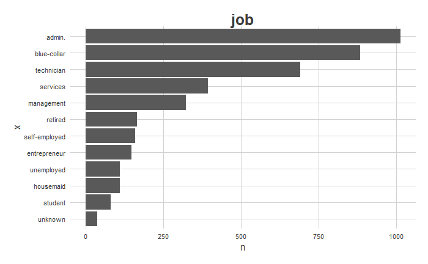

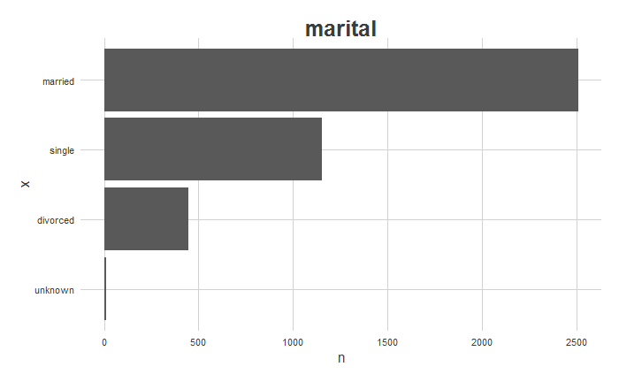

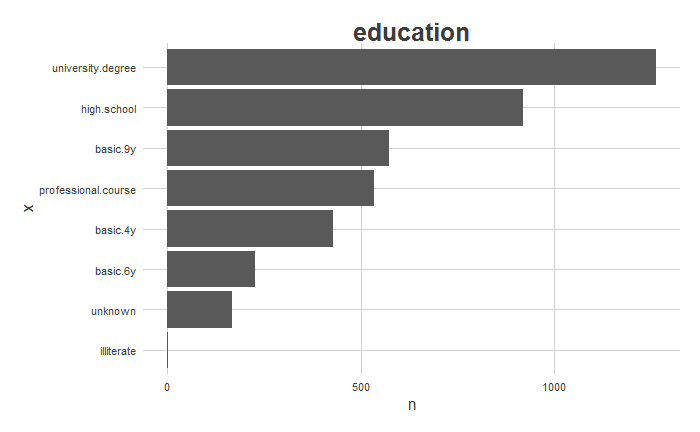

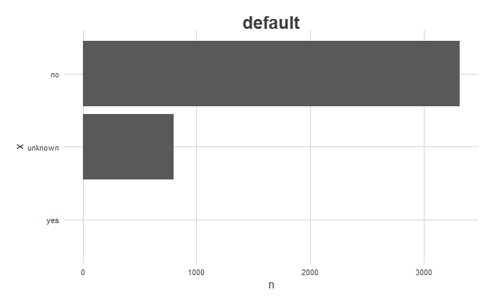

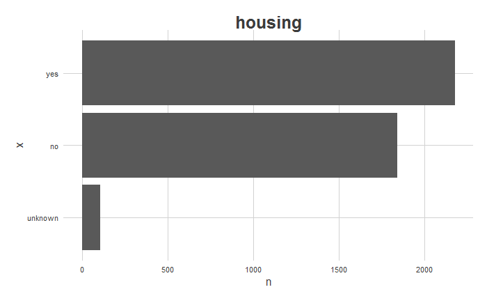

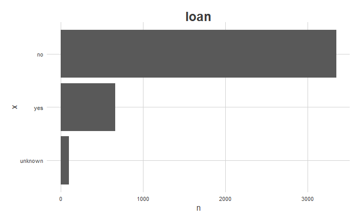

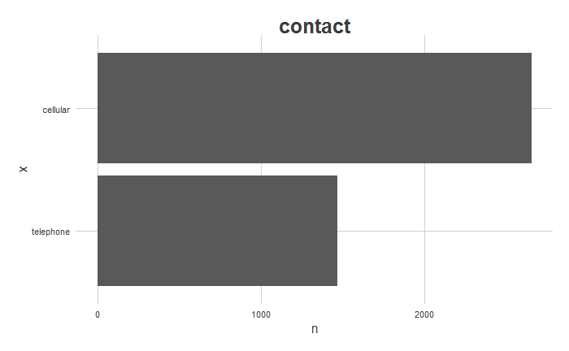

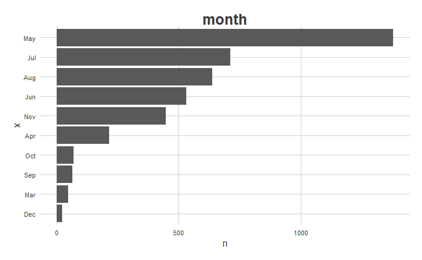

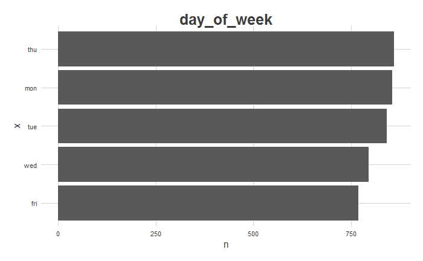

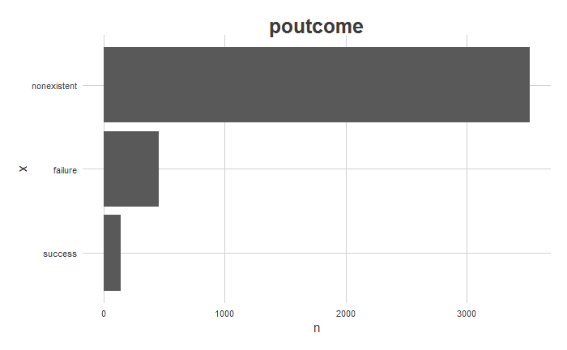

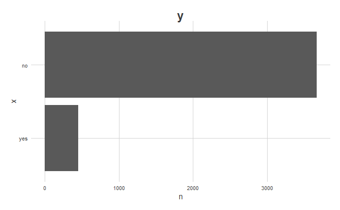

```r
data %>%
  select(where(is.factor)) %>%

  imap(function(feature_value, feature_name) {

    count(data.frame(x = feature_value), x) %>%
    mutate(x = fct_reorder(x, n)) %>%

      ggplot(aes(x = x, y = n)) +
      geom_col() +
      coord_flip() +
      labs(title = feature_name)
  })
```

```r
skim(data)
```

```
-- Data Summary ------------------------
                           Values
Name                       data
Number of rows             4119
Number of columns          21
_______________________
Column type frequency:
  factor                   11
  numeric                  10
________________________
Group variables            None

-- Variable type: factor -------------------------------------------------------------------------------
# A tibble: 11 x 6
   skim_variable n_missing complete_rate ordered n_unique top_counts
 * <chr>             <int>         <dbl> <lgl>      <int> <chr>
 1 job                   0             1 FALSE         12 adm: 1012, blu: 884, tec: 691, ser: 393
 2 marital               0             1 FALSE          4 mar: 2509, sin: 1153, div: 446, unk: 11
 3 education             0             1 FALSE          8 uni: 1264, hig: 921, bas: 574, pro: 535
 4 default               0             1 FALSE          3 no: 3315, unk: 803, yes: 1
 5 housing               0             1 FALSE          3 yes: 2175, no: 1839, unk: 105
 6 loan                  0             1 FALSE          3 no: 3349, yes: 665, unk: 105
 7 contact               0             1 FALSE          2 cel: 2652, tel: 1467
 8 month                 0             1 FALSE         10 May: 1378, Jul: 711, Aug: 636, Jun: 530
 9 day_of_week           0             1 FALSE          5 thu: 860, mon: 855, tue: 841, wed: 795
10 poutcome              0             1 FALSE          3 non: 3523, fai: 454, suc: 142
11 y                     0             1 FALSE          2 no: 3668, yes: 451

-- Variable type: numeric ------------------------------------------------------------------------------
# A tibble: 10 x 11
   skim_variable  n_missing complete_rate      mean      sd       p0     p25     p50     p75    p100
 * <chr>              <int>         <dbl>     <dbl>   <dbl>    <dbl>   <dbl>   <dbl>   <dbl>   <dbl>
 1 age                    0             1   40.1     10.3     18       32      38      47      88
 2 duration               0             1  257.     255.       0      103     181     317    3643
 3 campaign               0             1    2.54     2.57     1        1       2       3      35
 4 pdays                  0             1  960.     192.       0      999     999     999     999
 5 previous               0             1    0.190    0.542    0        0       0       0       6
 6 emp.var.rate           0             1    0.0850   1.56    -3.4     -1.8     1.1     1.4     1.4
 7 cons.price.idx         0             1   93.6      0.579   92.2     93.1    93.7    94.0    94.8
 8 cons.conf.idx          0             1  -40.5      4.59   -50.8    -42.7   -41.8   -36.4   -26.9
 9 euribor3m              0             1    3.62     1.73     0.635    1.33    4.86    4.96    5.04
10 nr.employed            0             1 5166.      73.7   4964.    5099.   5191    5228.   5228.
   hist
 * <chr>
 1 ▅▇▅▁▁
 2 ▇▁▁▁▁
 3 ▇▁▁▁▁
 4 ▁▁▁▁▇
 5 ▇▁▁▁▁
 6 ▁▃▁▁▇
 7 ▁▆▃▇▂
 8 ▅▇▁▇▁
 9 ▅▁▁▁▇
10 ▁▁▃▁▇
```

# splitting data - Train Test

```r
set.seed(123)

data_split_index <- createDataPartition(data$y, p = 0.7, list = FALSE)

train <- data[data_split_index,]
test <- data[-data_split_index,]

dim(train)
```

```
[1] 2884   21
```

```r
dim(test)
```

```
[1] 1235   21
```

```r
y_train = subset(train, select = y)
X_train = subset(train, select = -y)
```

```r
y_test = subset(test, select = y)
X_test = subset(test, select = -y)
```

## Exploring Train data

```r
summary(train)
```

```
      age                 job          marital                   education      default
 Min.   :19.00   admin.     :713   divorced: 301   university.degree  :872   no     :2324
 1st Qu.:32.00   blue-collar:609   married :1729   high.school        :656   unknown: 560
 Median :38.00   technician :490   single  : 848   basic.9y           :396   yes    :   0
 Mean   :40.05   services   :287   unknown :   6   professional.course:380
 3rd Qu.:47.00   management :228                   basic.4y           :299
 Max.   :88.00   retired    :110                   basic.6y           :159
                 (Other)    :447                   (Other)            :122
    housing          loan           contact         month     day_of_week    duration
 no     :1301   no     :2358   cellular :1867   May    :967   fri:517     Min.   :   0.0
 unknown:  69   unknown:  69   telephone:1017   Jul    :508   mon:619     1st Qu.: 102.0
 yes    :1514   yes    : 457                    Aug    :452   thu:598     Median : 180.0
                                                Jun    :359   tue:583     Mean   : 256.3
                                                Nov    :311   wed:567     3rd Qu.: 321.2
                                                Apr    :147               Max.   :1980.0
                                                (Other):140
    campaign          pdays          previous             poutcome     emp.var.rate
 Min.   : 1.000   Min.   :  0.0   Min.   :0.0000   failure    : 315   Min.   :-3.40000
 1st Qu.: 1.000   1st Qu.:999.0   1st Qu.:0.0000   nonexistent:2470   1st Qu.:-1.80000
 Median : 2.000   Median :999.0   Median :0.0000   success    :  99   Median : 1.10000
 Mean   : 2.551   Mean   :960.8   Mean   :0.1862                      Mean   : 0.08925
 3rd Qu.: 3.000   3rd Qu.:999.0   3rd Qu.:0.0000                      3rd Qu.: 1.40000
 Max.   :35.000   Max.   :999.0   Max.   :6.0000                      Max.   : 1.40000

 cons.price.idx  cons.conf.idx      euribor3m      nr.employed     y
 Min.   :92.20   Min.   :-50.80   Min.   :0.635   Min.   :4964   no :2568
 1st Qu.:93.08   1st Qu.:-42.70   1st Qu.:1.334   1st Qu.:5099   yes: 316
 Median :93.75   Median :-41.80   Median :4.857   Median :5191
 Mean   :93.57   Mean   :-40.44   Mean   :3.628   Mean   :5167
 3rd Qu.:93.99   3rd Qu.:-36.40   3rd Qu.:4.961   3rd Qu.:5228
 Max.   :94.77   Max.   :-26.90   Max.   :4.970   Max.   :5228
```

### featureplot

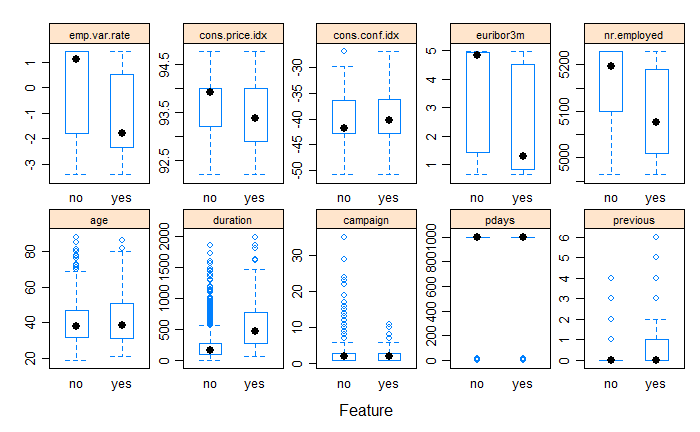

```r
train %>%
  select_if(is.numeric) %>%
  featurePlot(x = .,
              y = train$y,
              plot = "box",
              strip=strip.custom(par.strip.text=list(cex=.7)),
              scales = list(x = list(relation="free"),
                            y = list(relation="free"))
              )
```

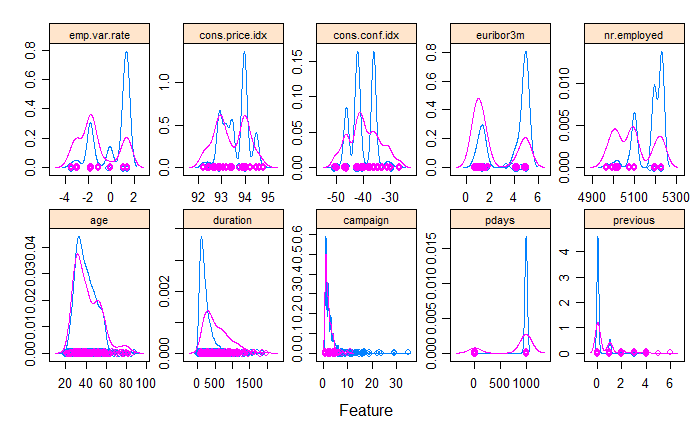

```r
train %>%
  select_if(is.numeric) %>%
  featurePlot(x = .,
              y = train$y,
              plot = "density",
              strip=strip.custom(par.strip.text=list(cex=.7)),
              scales = list(x = list(relation="free"),
                            y = list(relation="free"))
              )
```

# Data Pre Processing

## impute missing values

```r
# pp_impute <- preProcess(train, method = "knnIknnImpute")
#
library(RANN)
#
# train <- predict(pp_impute, newdata = train)
# anyNA(train)
```

## Outlier treatment

from: E:\3. RPractice\1.DataPreProcessing_HousingPrices.Rmd

```r
# outlier_cap <- function(x, na.rm = TRUE){
#
#   upper_cap = 3 * quantile(x, 0.99, na.rm = T)
#   lower_cap = 0.3 * quantile(x, 0.01, na.rm = T)
#
#   x[x > upper_cap] = upper_cap
#   x[x < lower_cap] = lower_cap
#
#   x <- x
# }
```

from: https://stackoverflow.com/questions/13339685/how-to-replace-outliers-with-the-5th-and-95th-percentile-values-in-r

```r
# outlier_cap <- function(x) {
#   quantiles <- quantile(x, c(0.05, 0.95) )
#
#   x[x < quantiles[1]] <- quantiles[1]
#   x[x > quantiles[2]] <- quantiles[2]
#
#   x
# }
```

```r
outlier_cap <- function(x, na.rm = TRUE){

  upper_cap = quantile(x, 0.99, na.rm = T)
  lower_cap = quantile(x, 0.01, na.rm = T)

  x[x > upper_cap] = upper_cap
  x[x < lower_cap] = lower_cap

  x <- x
}
```

```r
train <- train %>% mutate_if(is.numeric, outlier_cap)

# confirming if outlier capping worked or not
train %>% select_if(is.numeric) %>% summary(.)
```

```
      age           duration         campaign          pdays          previous       emp.var.rate
 Min.   :23.00   Min.   :  10.0   Min.   : 1.000   Min.   :  3.0   Min.   :0.0000   Min.   :-3.40000
 1st Qu.:32.00   1st Qu.: 102.0   1st Qu.: 1.000   1st Qu.:999.0   1st Qu.:0.0000   1st Qu.:-1.80000
 Median :38.00   Median : 180.0   Median : 2.000   Median :999.0   Median :0.0000   Median : 1.10000
 Mean   :39.97   Mean   : 253.6   Mean   : 2.506   Mean   :960.8   Mean   :0.1723   Mean   : 0.08925
 3rd Qu.:47.00   3rd Qu.: 321.2   3rd Qu.: 3.000   3rd Qu.:999.0   3rd Qu.:0.0000   3rd Qu.: 1.40000
 Max.   :67.17   Max.   :1196.4   Max.   :14.000   Max.   :999.0   Max.   :2.0000   Max.   : 1.40000
 cons.price.idx  cons.conf.idx      euribor3m      nr.employed
 Min.   :92.20   Min.   :-50.00   Min.   :0.659   Min.   :4964
 1st Qu.:93.08   1st Qu.:-42.70   1st Qu.:1.334   1st Qu.:5099
 Median :93.75   Median :-41.80   Median :4.857   Median :5191
 Mean   :93.57   Mean   :-40.46   Mean   :3.628   Mean   :5167
 3rd Qu.:93.99   3rd Qu.:-36.40   3rd Qu.:4.961   3rd Qu.:5228
 Max.   :94.47   Max.   :-29.31   Max.   :4.968   Max.   :5228
```

```r
levels(train$job)
```

```
 [1] "admin."        "blue-collar"   "entrepreneur"  "housemaid"     "management"    "retired"
 [7] "self-employed" "services"      "student"       "technician"    "unemployed"    "unknown"
```

```r
table(train$y)
```

```
  no  yes
2568  316
```

# Balancing data

```r
train_both_sample <- ROSE::ovun.sample(y ~ ., data = train, method = "both", p=0.5)$data
table(train_both_sample$y)
```

```
  no  yes
1489 1395
```

## One Hot Encoding

```r
Y = subset(data, select = y)
X = subset(data, select = -y)
```

```r
dim(X)
```

```
[1] 4119   20
```

```r
dim(Y)
```

```
[1] 4119    1
```

```r
typeof(Y)
```

```
[1] "list"
```

```r
class(Y)
```

```
[1] "data.frame"
```

```r
class(data$age)
```

```
[1] "integer"
```

```r
class(as.factor(Y))
```

```
[1] "factor"
```

```r
Y_train = subset(train_both_sample, select = y)
X_train = subset(train_both_sample, select = -y)
```

```r
Y_test = subset(test, select = y)
X_test = subset(test, select = -y)
```

```r
pp_dummy <- dummyVars(y ~ ., data = train_both_sample)

train_both_sample <- predict(pp_dummy, newdata = train_both_sample)
train_both_sample <- data.frame(train_both_sample)

test <- predict(pp_dummy, newdata = test)
test <- data.frame(test)

str(train_both_sample)
```

```
'data.frame':   2884 obs. of  63 variables:
 $ age                          : num  43 25 40 45 37 36 33 34 30 41 ...
 $ job.admin.                   : num  0 0 0 0 1 1 1 0 1 0 ...
 $ job.blue.collar              : num  0 0 0 0 0 0 0 1 0 0 ...
 $ job.entrepreneur             : num  0 0 0 0 0 0 0 0 0 0 ...
 $ job.housemaid                : num  0 0 0 0 0 0 0 0 0 0 ...
 $ job.management               : num  1 0 1 0 0 0 0 0 0 1 ...
 $ job.retired                  : num  0 0 0 0 0 0 0 0 0 0 ...
 $ job.self.employed            : num  0 1 0 0 0 0 0 0 0 0 ...
 $ job.services                 : num  0 0 0 0 0 0 0 0 0 0 ...
 $ job.student                  : num  0 0 0 0 0 0 0 0 0 0 ...
 $ job.technician               : num  0 0 0 0 0 0 0 0 0 0 ...
 $ job.unemployed               : num  0 0 0 1 0 0 0 0 0 0 ...
 $ job.unknown                  : num  0 0 0 0 0 0 0 0 0 0 ...
 $ marital.divorced             : num  0 0 0 0 0 0 0 0 0 0 ...
```

[output cut: 49 more lines]

# Variables Selection

## Near Zero Variance

from: https://topepo.github.io/caret/pre-processing.html

```r
nzv <- nearZeroVar(train_both_sample, saveMetrics = TRUE)
nzv
```

|  | freqRatio | percentUnique | zeroVar | nzv |
| --- | --- | --- | --- | --- |
| age | 1.156028 | 1.56033287 | FALSE | FALSE |
| job.admin. | 2.774869 | 0.06934813 | FALSE | FALSE |
| job.blue.collar | 4.350649 | 0.06934813 | FALSE | FALSE |
| job.entrepreneur | 33.746988 | 0.06934813 | FALSE | TRUE |
| job.housemaid | 57.857143 | 0.06934813 | FALSE | TRUE |
| job.management | 12.351852 | 0.06934813 | FALSE | FALSE |
| job.retired | 16.166667 | 0.06934813 | FALSE | FALSE |
| job.self.employed | 33.746988 | 0.06934813 | FALSE | TRUE |
| job.services | 9.924242 | 0.06934813 | FALSE | FALSE |
| job.student | 29.041667 | 0.06934813 | FALSE | TRUE |

[output cut: 53 more lines]

```r
nzv_list <- nearZeroVar(train_both_sample) %>%
            as.vector()

nzv_list
```

```
 [1]  4  5  8 10 12 13 17 19 22 25 28 30 33 37 43 44 46
```

```r
selected_vars <- train_both_sample[, -nzv_list ]

str(selected_vars)
```

```
'data.frame':   2884 obs. of  46 variables:
 $ age                          : num  43 25 40 45 37 36 33 34 30 41 ...
 $ job.admin.                   : num  0 0 0 0 1 1 1 0 1 0 ...
 $ job.blue.collar              : num  0 0 0 0 0 0 0 1 0 0 ...
 $ job.management               : num  1 0 1 0 0 0 0 0 0 1 ...
 $ job.retired                  : num  0 0 0 0 0 0 0 0 0 0 ...
 $ job.services                 : num  0 0 0 0 0 0 0 0 0 0 ...
 $ job.technician               : num  0 0 0 0 0 0 0 0 0 0 ...
 $ marital.divorced             : num  0 0 0 0 0 0 0 0 0 0 ...
 $ marital.married              : num  1 0 1 1 0 1 1 1 0 1 ...
 $ marital.single               : num  0 1 0 0 1 0 0 0 1 0 ...
 $ education.basic.4y           : num  0 0 0 1 0 0 0 0 0 0 ...
 $ education.basic.9y           : num  0 0 0 0 0 0 0 1 0 0 ...
 $ education.high.school        : num  0 0 0 0 0 1 0 0 0 1 ...
 $ education.professional.course: num  0 0 0 0 1 0 0 0 0 0 ...
```

[output cut: 32 more lines]

append y to train

```r
selected_vars$y <- Y_train # as.factor(Y)

str(selected_vars)
```

```
'data.frame':   2884 obs. of  47 variables:
 $ age                          : num  43 25 40 45 37 36 33 34 30 41 ...
 $ job.admin.                   : num  0 0 0 0 1 1 1 0 1 0 ...
 $ job.blue.collar              : num  0 0 0 0 0 0 0 1 0 0 ...
 $ job.management               : num  1 0 1 0 0 0 0 0 0 1 ...
 $ job.retired                  : num  0 0 0 0 0 0 0 0 0 0 ...
 $ job.services                 : num  0 0 0 0 0 0 0 0 0 0 ...
 $ job.technician               : num  0 0 0 0 0 0 0 0 0 0 ...
 $ marital.divorced             : num  0 0 0 0 0 0 0 0 0 0 ...
 $ marital.married              : num  1 0 1 1 0 1 1 1 0 1 ...
 $ marital.single               : num  0 1 0 0 1 0 0 0 1 0 ...
 $ education.basic.4y           : num  0 0 0 1 0 0 0 0 0 0 ...
 $ education.basic.9y           : num  0 0 0 0 0 0 0 1 0 0 ...
 $ education.high.school        : num  0 0 0 0 0 1 0 0 0 1 ...
 $ education.professional.course: num  0 0 0 0 1 0 0 0 0 0 ...
```

[output cut: 34 more lines]

```r
# data <- data %>% mutate(y = as.factor(y))

# str(data)
```

Since appending Y as factor is causing NA in the oclumn so quiting this step of adding Y as factor

```r
anyNA(selected_vars)
```

```
[1] FALSE
```

## RFE

https://www.machinelearningplus.com/machine-learning/caret-package/

http://topepo.github.io/caret/recursive-feature-elimination.html#rfe

this also took around 32 mins

```r
control <- rfeControl(functions = rfFuncs, method = "cv", verbose = FALSE)

system.time(
  RFE_both_smpl_res <- rfe(x = subset(selected_vars, select = -y),    #  selected_vars[, 1:44]
                 y = pull(selected_vars$y),
                 sizes = c(7, 15, 20),
                 rfeControl = control
                 )
)
```

```r
RFE_both_smpl_res
```

```
Recursive feature selection

Outer resampling method: Cross-Validated (10 fold)

Resampling performance over subset size:
```

|  | Variables | Accuracy | Kappa | AccuracySD | KappaSD | Selected |
| --- | --- | --- | --- | --- | --- | --- |
| 1 | 7 | 0.9574 | 0.9148 | 0.01232 | 0.02458 |  |
| 2 | 15 | 0.9674 | 0.9349 | 0.01006 | 0.02005 |  |
| 3 | 20 | 0.9681 | 0.9363 | 0.00813 | 0.01621 |  |
| 4 | 46 | 0.9698 | 0.9397 | 0.01033 | 0.02059 | * |

```
The top 5 variables (out of 46):
   duration, age, campaign, euribor3m, cons.conf.idx
```

```r
RFE_both_smpl_res$optVariables
```

```
 [1] "duration"                      "age"                           "campaign"
 [4] "euribor3m"                     "cons.conf.idx"                 "cons.price.idx"
 [7] "nr.employed"                   "day_of_week.thu"               "day_of_week.wed"
[10] "day_of_week.fri"               "day_of_week.tue"               "marital.single"
[13] "job.admin."                    "housing.no"                    "emp.var.rate"
[16] "day_of_week.mon"               "education.high.school"         "education.university.degree"
[19] "housing.yes"                   "job.technician"                "marital.married"
[22] "education.professional.course" "job.retired"                   "loan.no"
[25] "loan.yes"                      "pdays"                         "month.May"
[28] "education.basic.9y"            "default.unknown"               "default.no"
[31] "education.basic.4y"            "contact.cellular"              "marital.divorced"
[34] "job.blue.collar"               "poutcome.failure"              "contact.telephone"
[37] "previous"                      "job.management"                "poutcome.success"
[40] "month.Jun"                     "job.services"                  "poutcome.nonexistent"
[43] "month.Aug"                     "month.Apr"                     "month.Nov"
[46] "month.Jul"
```

```r
predictors(RFE_both_smpl_res)
```

```
 [1] "duration"                      "age"                           "campaign"
 [4] "euribor3m"                     "cons.conf.idx"                 "cons.price.idx"
 [7] "nr.employed"                   "day_of_week.thu"               "day_of_week.wed"
[10] "day_of_week.fri"               "day_of_week.tue"               "marital.single"
[13] "job.admin."                    "housing.no"                    "emp.var.rate"
[16] "day_of_week.mon"               "education.high.school"         "education.university.degree"
[19] "housing.yes"                   "job.technician"                "marital.married"
[22] "education.professional.course" "job.retired"                   "loan.no"
[25] "loan.yes"                      "pdays"                         "month.May"
[28] "education.basic.9y"            "default.unknown"               "default.no"
[31] "education.basic.4y"            "contact.cellular"              "marital.divorced"
[34] "job.blue.collar"               "poutcome.failure"              "contact.telephone"
[37] "previous"                      "job.management"                "poutcome.success"
[40] "month.Jun"                     "job.services"                  "poutcome.nonexistent"
[43] "month.Aug"                     "month.Apr"                     "month.Nov"
[46] "month.Jul"
```

```r
RFE_both_smpl_res$optVariables[1:15]
```

```
 [1] "duration"        "age"             "campaign"        "euribor3m"       "cons.conf.idx"
 [6] "cons.price.idx"  "nr.employed"     "day_of_week.thu" "day_of_week.wed" "day_of_week.fri"
[11] "day_of_week.tue" "marital.single"  "job.admin."      "housing.no"      "emp.var.rate"
```

```r
RFE_both_smpl_res$optVariables[1:15] %>% as.vector()
```

```
 [1] "duration"        "age"             "campaign"        "euribor3m"       "cons.conf.idx"
 [6] "cons.price.idx"  "nr.employed"     "day_of_week.thu" "day_of_week.wed" "day_of_week.fri"
[11] "day_of_week.tue" "marital.single"  "job.admin."      "housing.no"      "emp.var.rate"
```

[output not shown]

[output cut: 870 more lines]

```r
RFE_both_smpl_res$variables$var[1:15]
```

```
 [1] "duration"        "age"             "euribor3m"       "campaign"        "cons.price.idx"
 [6] "cons.conf.idx"   "nr.employed"     "day_of_week.thu" "housing.no"      "marital.single"
[11] "day_of_week.mon" "day_of_week.tue" "emp.var.rate"    "job.admin."      "day_of_week.wed"
```

## Normalize / center / scale

```r
pp_standardize <- preProcess(train_both_sample, method = c("center","scale"))

train_both_sample <- predict(pp_standardize, newdata = train_both_sample)

str(train_both_sample)
```

```
'data.frame':   2884 obs. of  63 variables:
 $ age                          : num  0.2376 -1.3924 -0.0341 0.4187 -0.3057 ...
 $ job.admin.                   : num  -0.6 -0.6 -0.6 -0.6 1.67 ...
 $ job.blue.collar              : num  -0.479 -0.479 -0.479 -0.479 -0.479 ...
 $ job.entrepreneur             : num  -0.172 -0.172 -0.172 -0.172 -0.172 ...
 $ job.housemaid                : num  -0.131 -0.131 -0.131 -0.131 -0.131 ...
 $ job.management               : num  3.514 -0.284 3.514 -0.284 -0.284 ...
 $ job.retired                  : num  -0.249 -0.249 -0.249 -0.249 -0.249 ...
 $ job.self.employed            : num  -0.172 5.808 -0.172 -0.172 -0.172 ...
 $ job.services                 : num  -0.317 -0.317 -0.317 -0.317 -0.317 ...
 $ job.student                  : num  -0.186 -0.186 -0.186 -0.186 -0.186 ...
 $ job.technician               : num  -0.458 -0.458 -0.458 -0.458 -0.458 ...
 $ job.unemployed               : num  -0.189 -0.189 -0.189 5.275 -0.189 ...
 $ job.unknown                  : num  -0.0856 -0.0856 -0.0856 -0.0856 -0.0856 ...
 $ marital.divorced             : num  -0.333 -0.333 -0.333 -0.333 -0.333 ...
```

[output cut: 49 more lines]

```r
pp_range <- preProcess(train_both_sample, method = c("range"))

train_both_sample <- predict(pp_range, newdata = train_both_sample)

str(train_both_sample)
```

```
'data.frame':   2884 obs. of  63 variables:
 $ age                          : num  0.4528 0.0453 0.3849 0.4981 0.317 ...
 $ job.admin.                   : num  0 0 0 0 1 1 1 0 1 0 ...
 $ job.blue.collar              : num  0 0 0 0 0 0 0 1 0 0 ...
 $ job.entrepreneur             : num  0 0 0 0 0 0 0 0 0 0 ...
 $ job.housemaid                : num  0 0 0 0 0 0 0 0 0 0 ...
 $ job.management               : num  1 0 1 0 0 0 0 0 0 1 ...
 $ job.retired                  : num  0 0 0 0 0 0 0 0 0 0 ...
 $ job.self.employed            : num  0 1 0 0 0 0 0 0 0 0 ...
 $ job.services                 : num  0 0 0 0 0 0 0 0 0 0 ...
 $ job.student                  : num  0 0 0 0 0 0 0 0 0 0 ...
 $ job.technician               : num  0 0 0 0 0 0 0 0 0 0 ...
 $ job.unemployed               : num  0 0 0 1 0 0 0 0 0 0 ...
 $ job.unknown                  : num  0 0 0 0 0 0 0 0 0 0 ...
 $ marital.divorced             : num  0 0 0 0 0 0 0 0 0 0 ...
```

[output cut: 49 more lines]

append y to train

```r
train_both_sample$y <- Y_train # as.factor(Y)

str(train_both_sample)
```

```
'data.frame':   2884 obs. of  64 variables:
 $ age                          : num  0.4528 0.0453 0.3849 0.4981 0.317 ...
 $ job.admin.                   : num  0 0 0 0 1 1 1 0 1 0 ...
 $ job.blue.collar              : num  0 0 0 0 0 0 0 1 0 0 ...
 $ job.entrepreneur             : num  0 0 0 0 0 0 0 0 0 0 ...
 $ job.housemaid                : num  0 0 0 0 0 0 0 0 0 0 ...
 $ job.management               : num  1 0 1 0 0 0 0 0 0 1 ...
 $ job.retired                  : num  0 0 0 0 0 0 0 0 0 0 ...
 $ job.self.employed            : num  0 1 0 0 0 0 0 0 0 0 ...
 $ job.services                 : num  0 0 0 0 0 0 0 0 0 0 ...
 $ job.student                  : num  0 0 0 0 0 0 0 0 0 0 ...
 $ job.technician               : num  0 0 0 0 0 0 0 0 0 0 ...
 $ job.unemployed               : num  0 0 0 1 0 0 0 0 0 0 ...
 $ job.unknown                  : num  0 0 0 0 0 0 0 0 0 0 ...
 $ marital.divorced             : num  0 0 0 0 0 0 0 0 0 0 ...
```

[output cut: 51 more lines]

# Modeling

## MARS Model

```r
RFE_both_smpl_res$optVariables
```

```
 [1] "duration"                      "age"                           "campaign"
 [4] "euribor3m"                     "cons.conf.idx"                 "cons.price.idx"
 [7] "nr.employed"                   "day_of_week.thu"               "day_of_week.wed"
[10] "day_of_week.fri"               "day_of_week.tue"               "marital.single"
[13] "job.admin."                    "housing.no"                    "emp.var.rate"
[16] "day_of_week.mon"               "education.high.school"         "education.university.degree"
[19] "housing.yes"                   "job.technician"                "marital.married"
[22] "education.professional.course" "job.retired"                   "loan.no"
[25] "loan.yes"                      "pdays"                         "month.May"
[28] "education.basic.9y"            "default.unknown"               "default.no"
[31] "education.basic.4y"            "contact.cellular"              "marital.divorced"
[34] "job.blue.collar"               "poutcome.failure"              "contact.telephone"
[37] "previous"                      "job.management"                "poutcome.success"
[40] "month.Jun"                     "job.services"                  "poutcome.nonexistent"
[43] "month.Aug"                     "month.Apr"                     "month.Nov"
[46] "month.Jul"
```

### Hyper Parameter tuning & train Control

```r
fitCtrl <- trainControl(
  method = "cv",
  # repeats = 5,
  number = 10,
  savePredictions = "final",
  classProbs = TRUE,
  summaryFunction = twoClassSummary
)
```

took less than 2 min to run

```r
set.seed(123)

system.time(
model_mars_1_both_smpl <- train(pull(y) ~
duration+age+campaign+euribor3m+cons.conf.idx,
                      data = train_both_sample,
                      method = "earth",
                      tuneLength = 10,
                      metric = "Spec",
                      trControl = fitCtrl
                      )
)
```

```r
# saveRDS(model_mars_1_both_smpl,"model_mars_1_both_smpl.rds")

model_mars_1_both_smpl <- readRDS("model_mars_1_both_smpl.rds")
```

```r
model_mars_1_both_smpl
```

```
Multivariate Adaptive Regression Spline

2884 samples
   5 predictor
   2 classes: 'no', 'yes'

No pre-processing
Resampling: Cross-Validated (10 fold)
Summary of sample sizes: 2596, 2596, 2595, 2596, 2596, 2596, ...
Resampling results across tuning parameters:

  nprune  ROC        Sens       Spec
   2      0.7908668  0.7930619  0.6688232
   3      0.8849366  0.7138944  0.9003905
   4      0.9167996  0.8246962  0.8566752
   5      0.9318444  0.8401642  0.8752980
   6      0.9341297  0.8441955  0.8867523
   8      0.9421205  0.8509206  0.9025128
   9      0.9443541  0.8522628  0.9061100
  10      0.9442885  0.8509206  0.9039671
  11      0.9443178  0.8542763  0.9068294
  13      0.9461217  0.8536051  0.9046814

Tuning parameter 'degree' was held constant at a value of 1
Spec was used to select the optimal model using the largest value.
The final values used for the model were nprune = 11 and degree = 1.
```

```r
table(predict(model_mars_1_both_smpl, newdata = train_both_sample, type = "raw"))
```

```
  no  yes
1401 1483
```

```r
test1 <- test %>%
  select(duration,age,campaign,euribor3m,cons.conf.idx,y)

str(test1)
```

```
'data.frame':   1235 obs. of  6 variables:
 $ duration     : num  227 128 148 211 222 119 127 340 412 157 ...
 $ age          : num  25 32 36 47 39 40 47 32 39 32 ...
 $ campaign     : num  1 3 1 2 1 1 1 1 2 3 ...
 $ euribor3m    : num  4.962 0.884 4.968 4.958 0.639 ...
 $ cons.conf.idx: num  -41.8 -37.5 -42.7 -41.8 -34.8 -36.1 -36.4 -46.2 -46.2 -42.7 ...
 $ y            :'data.frame':  1235 obs. of  1 variable:
  ..$ y: Factor w/ 2 levels "no","yes": 1 1 1 1 2 1 1 1 1 1 ...
```

```r
mars_1_both_pred_class <- predict(model_mars_1_both_smpl, newdata = test1)
table(mars_1_both_pred_class)
```

```
mars_1_both_pred_class
  no  yes
   0 1235
```

```r
mars_1_both_pred_class <- predict(model_mars_1_both_smpl, newdata = test)
table(mars_1_both_pred_class)
```

```
mars_1_both_pred_class
  no  yes
   0 1235
```

[output not shown]

[output cut: 990 more lines]

## MARS Model 2 (inc. tuneGrid)

took more than 2 minute to run

```r
# set.seed(123)
#
# tune_params <- expand.grid(nprune = c(3,7,10,14,18,25),
#                            degree = 1)
#
# system.time(
# model_mars_2_pp_undr_smpl <- train(pull(y) ~ duration+nr.employed+euribor3m+emp.var.rate+cons.conf.idx+previous+contact.telephone,
#                       data = train_under_sample,
#                       method = "earth",
#                       tuneGrid =  tune_params,
#                       metric = "Spec",
#                       trControl = fitCtrl
#                       )
# )
```

```r
# saveRDS(model_mars_2_pp_undr_smpl,"model_mars_2_pp_undr_smpl.rds")

# model_mars_2_pp_undr_smpl <- readRDS("model_mars_2_pp_undr_smpl.rds")
```

```r
# model_mars_2_pp_undr_smpl
```

[1] “duration” “age” “euribor3m” “campaign” “cons.price.idx” [6] “cons.conf.idx” “nr.employed” “day_of_week.thu” “housing.no” “marital.single” [11] “day_of_week.mon” “day_of_week.tue” “emp.var.rate” “job.admin.” “day_of_week.wed”

## MARS Model 3 (incr. features)

took less than 3 minute to run

```r
set.seed(123)

system.time(
model_mars_3_pp_both_smpl <- train(pull(y) ~ duration+age+euribor3m+campaign+cons.price.idx+cons.conf.idx+nr.employed+day_of_week.thu+housing.no+marital.single+day_of_week.mon+day_of_week.tue+emp.var.rate+job.admin.+day_of_week.wed,
                      data = train_under_sample,
                      method = "earth",
                      tuneLength = 10,
                      metric = "Spec",
                      trControl = fitCtrl,
                      # preProcess = c("center","scale")
                      )
)
```

```r
# saveRDS(model_mars_3_pp_both_smpl,"model_mars_3_pp_both_smpl.rds")

model_mars_3_pp_both_smpl <- readRDS("model_mars_3_pp_both_smpl.rds")
```

```r
model_mars_3_pp_both_smpl
```

```
Multivariate Adaptive Regression Spline

632 samples
 15 predictor
  2 classes: 'no', 'yes'

No pre-processing
Resampling: Cross-Validated (10 fold)
Summary of sample sizes: 568, 569, 569, 569, 569, 569, ...
Resampling results across tuning parameters:

  nprune  ROC        Sens       Spec
   2      0.8079558  0.7341734  0.7406250
   3      0.8835670  0.7683468  0.8726815
   5      0.9251386  0.8417339  0.8924395
   7      0.9323463  0.8546371  0.9016129
   9      0.9351310  0.8513105  0.9145161
  10      0.9318076  0.8450605  0.9114919
  12      0.9312027  0.8450605  0.9178427
  14      0.9312027  0.8450605  0.9178427
  16      0.9312027  0.8450605  0.9178427
  18      0.9312027  0.8450605  0.9178427

Tuning parameter 'degree' was held constant at a value of 1
Spec was used to select the optimal model using the largest value.
The final values used for the model were nprune = 12 and degree = 1.
```

```r
table(predict(model_mars_3_pp_both_smpl, newdata = train_both_sample, type = "raw"))
```

```
  no  yes
1356 1528
```

```r
test %>%
  select(duration+age+euribor3m+campaign+cons.price.idx+cons.conf.idx+nr.employed+day_of_week.thu+housing.no+marital.single+day_of_week.mon+day_of_week.tue+emp.var.rate+job.admin.+day_of_week.wed)
```

```r
table(predict(model_mars_3_pp_both_smpl, newdata = test, type = "raw"))
```

```
  no  yes
   0 1235
```

## MARS Model 4 (inc. tuneGrid)

took less than 3 minute to run

```r
set.seed(123)

tune_params <- expand.grid(nprune = c(3,7,10,14,18,25,30),
                           degree = 1)

system.time(
model_mars_4_pp_undr_smpl <- train(pull(y) ~ duration+nr.employed+euribor3m+pdays+emp.var.rate+poutcome.success+month.Mar+cons.conf.idx+contact.telephone+contact.cellular+previous+age+cons.price.idx+month.Jun+job.retired,
                      data = train_under_sample,
                      method = "earth",
                      tuneGrid = tune_params,
                      metric = "Spec",
                      trControl = fitCtrl
                      )
)
```

```r
# saveRDS(model_mars_4_pp_undr_smpl,"model_mars_4_pp_undr_smpl.rds")

model_mars_4_pp_undr_smpl <- readRDS("model_mars_4_pp_undr_smpl.rds")
```

```r
model_mars_4_pp_undr_smpl
```

### VIF check

```r
library(car)
```

from: https://stats.stackexchange.com/questions/112442/what-are-aliased-coefficients

```r
alias_undr_smpl_res <- alias(
  lm( as.numeric(pull(y)) ~ duration+nr.employed+euribor3m+pdays+emp.var.rate+poutcome.success+month.Mar+cons.conf.idx+contact.telephone+contact.cellular+previous+age+cons.price.idx+month.Jun+job.retired, data = train_under_sample )
  )

alias_undr_smpl_res
```

from: https://stackoverflow.com/questions/28885160/vifs-returning-aliased-coefficients-in-r/32791536

```r
ld.vars <- attributes(alias_undr_smpl_res$Complete)$dimnames[[1]]
ld.vars
```

remove aliased variable and run model again

```r
model_vif_check_aliased <- train(as.numeric(pull(y)) ~ duration+nr.employed+euribor3m+pdays+emp.var.rate+poutcome.success+month.Mar+cons.conf.idx+contact.telephone+previous+age+cons.price.idx+month.Jun+job.retired,
                      data = train_under_sample,
                      method = "lm"
                      )

model_vif_check_aliased
```

```r
# saveRDS(model_vif_check_aliased, "model_vif_check_aliased.rds")

model_vif_check_aliased <- readRDS("model_vif_check_aliased.rds")
```

```r
vif_values <- car::vif(model_vif_check_aliased$finalModel)
vif_values
```

```r
vif_df <- as.data.frame(vif_values)
vif_df$var_names <- rownames(vif_df)

vif_df
```

```r
vif_df %>%
  ggplot(aes(x = fct_reorder(var_names, vif_values), y =vif_values)) +
  geom_col() +
  coord_flip() +
  geom_hline(yintercept = 2, color = "gray70", lty = 2)
```

Dropping variables one by one from highest vif and recalculating vif to vif < 1.5. Maximum allowed is 2.

```r
model_vif_check_aliased <- train(as.numeric(pull(y)) ~ duration+month.Mar+cons.conf.idx+contact.telephone+previous+age+cons.price.idx+month.Jun+job.retired,
                      data = train_under_sample,
                      method = "lm"
                      )

vif_values <- car::vif(model_vif_check_aliased$finalModel)

vif_df <- as.data.frame(vif_values)
vif_df$var_names <- rownames(vif_df)

vif_df %>%
  ggplot(aes(x = fct_reorder(var_names, vif_values), y =vif_values)) +
  geom_col() +
  coord_flip() +
  geom_hline(yintercept = 2, color = "gray70", lty = 2)
```

```r
# dropping: nr.employed+emp.var.rate+pdays+euribor3m+poutcome.success

model_vif_check_aliased <- train(as.numeric(pull(y)) ~ duration+month.Mar+cons.conf.idx+contact.telephone+previous+age+cons.price.idx+month.Jun+job.retired,
                      data = train_under_sample,
                      method = "lm"
                      )
```

```r
vif_values <- car::vif(model_vif_check_aliased$finalModel)

vif_df <- as.data.frame(vif_values)
vif_df$var_names <- rownames(vif_df)

vif_df %>%
  ggplot(aes(x = fct_reorder(var_names, vif_values), y =vif_values)) +
  geom_col() +
  coord_flip() +
  geom_hline(yintercept = 1.5, color = "gray70", lty = 2)
```

## MARS Model 5 (After VIF)

```r
set.seed(123)

tune_params <- expand.grid(nprune = c(3,7,10,14,18,25,30),
                           degree = 1)

system.time(
model_mars_5_undr_smpl <- train(pull(y) ~ duration+month.Mar+cons.conf.idx+contact.telephone+previous+age+cons.price.idx+month.Jun+job.retired,
                      data = train_under_sample,
                      method = "earth",
                      tuneGrid = tune_params,
                      metric = "Spec",
                      trControl = fitCtrl
                      )
)
```

```r
# saveRDS(model_mars_5_undr_smpl,"model_mars_5_undr_smpl.rds")

model_mars_5_undr_smpl <- readRDS("model_mars_5_undr_smpl.rds")
```

```r
model_mars_5_undr_smpl
```

### check pred. probability

```r
predict(model_mars_5_undr_smpl, newdata = train_under_sample, type = "prob") %>% head()
```

### check pred. class

```r
predict(model_mars_5_undr_smpl, newdata = train_under_sample, type = "raw") %>% head()
```

### TP,FP,TN,FN visual exploration

from: file:///E:/3.%20R/ML/tidytuesday%20Himalayan/r_Himalayan_tidytuesday-labversion.html

```r
mars5_pred_class <- predict(model_mars_5_undr_smpl, newdata = train_under_sample, type = "raw")

table(mars5_pred_class)
```

```r
cbind(train_under_sample$y,mars5_pred_class) %>% #head()

ggplot() +
  geom_density(aes(mars5_pred_class, fill = y), alpha = 0.5)
```

```r
mars5_pred_no_prob <- predict(model_mars_5_undr_smpl, newdata = train_under_sample, type = "prob")[,"no"]
head(mars5_pred_no_prob)
```

```r
cbind(train_under_sample$y,mars5_pred_no_prob) %>% head()
```

```r
df_test <- cbind(mars5_pred_no_prob, train_under_sample$y) %>%
            rename(prob = mars5_pred_no_prob, Class = y)

df_test <- as.data.frame(df_test)

head(df_test)
```

```r
plot_pred_type_distribution <- function(df_test, threshold = 0.5) {
  v <- rep(NA, nrow(df_test))
  v <- ifelse(df_test$prob >= threshold & df_test$Class == "no", "TP", v)
  v <- ifelse(df_test$prob >= threshold & df_test$Class == "yes", "FP", v)
  v <- ifelse(df_test$prob < threshold & df_test$Class == "no", "FN", v)
  v <- ifelse(df_test$prob < threshold & df_test$Class == "yes", "TN", v)

  df_test$pred_type <- v

  ggplot(data=df_test, aes(x=Class, y=prob)) +
    geom_violin(fill= "gray",alpha=0.6, color="NA") +
    geom_jitter(aes(color=pred_type), alpha=0.6) +
    geom_hline(yintercept=threshold, color="red", alpha=0.6) +
    scale_color_discrete(name = "type") +
    labs(title=sprintf("Results Tradeoff at Threshold %.2f", threshold)) +
    theme(text = element_text(size = 20))
}
```

```r
plot_pred_type_distribution(df_test, threshold = 0.7)
```

```r
plot_pred_type_distribution(df_test, threshold = 0.85)
```

```r
plot_pred_type_distribution(df_test, threshold = 0.9)
```

### change threshold

from: https://stackoverflow.com/questions/32128879/how-to-change-the-threshold-for-binary-classification

```r
confusionMatrix(table(predict(model_mars_5_undr_smpl, type="prob")[,"yes"] >= 0.25,
                      train_under_sample$y == "yes"))
```

```r
threshold_confmatrix <- function(threshold_major_class = 0.5){
  confusionMatrix(table(predict(model_mars_5_undr_smpl, type="prob")[,"yes"] >= (1- threshold_major_class),
                      train_under_sample$y == "yes"))
}
```

```r
threshold_confmatrix(0.75)
```

### change threshold (did not work)

from: https://stats.stackexchange.com/questions/112388/how-to-change-threshold-for-classification-in-r-randomforests

```r
mars4_pred <- predict(model_mars_4_pp, newdata = train, type = "prob")

cutoff = 0.7

mars4_pred[mars4_pred < cutoff] = "yes"
mars4_pred[mars4_pred > cutoff] = "no"

mars4_pred %>%  head()
```

## Adaboost Model

```r
set.seed(123)

system.time(
model_adaboost_1_undr_smpl <- train(pull(y) ~ duration+month.Mar+cons.conf.idx+contact.telephone+previous+age+cons.price.idx+month.Jun+job.retired,
                        data = train_under_sample,
                        method = "adaboost",
                        tuneLenth = 10,
                        metric = "Spec",
                        trControl = fitCtrl)
)
```

```r
# saveRDS(model_adaboost_1_undr_smpl,"model_adaboost_1_undr_smpl.rds")

model_adaboost_1_undr_smpl <- readRDS("model_adaboost_1_undr_smpl.rds")
```

```r
model_adaboost_1_undr_smpl
```

### Knn Model

```r
set.seed(123)

system.time(
model_knn_undr_smpl <- train(pull(y) ~
duration+month.Mar+cons.conf.idx+contact.telephone+previous+age+cons.price.idx+month.Jun+job.retired,
                        data = train_under_sample,
                        method = "kknn",
                        tuneLenth = 10,
                        metric = "Spec",
                        trControl = fitCtrl)
)
```

```r
saveRDS(model_knn_undr_smpl,"model_knn_undr_smpl.rds")

model_knn_undr_smpl <- readRDS("model_knn_undr_smpl.rds")
```

```r
model_knn_undr_smpl
```

### DT Model

from: https://rpubs.com/maulikpatel/229337

```r
set.seed(123)

system.time(
model_dt_undr_smpl <- train(pull(y) ~
duration+month.Mar+cons.conf.idx+contact.telephone+previous+age+cons.price.idx+month.Jun+job.retired,
                        data = train_under_sample,
                        method = "rpart",
                        # tuneLenth = 10,  # tunLength with Dt gives errors
                        metric = "Spec",
                        trControl = fitCtrl)
)
```

```r
# saveRDS(model_dt_undr_smpl,"model_dt_undr_smpl.rds")

model_dt_undr_smpl <- readRDS("model_dt_undr_smpl.rds")
```

```r
model_dt_undr_smpl
```

```r
plot(model_dt_undr_smpl)
```

```r
# from: https://rpubs.com/maulikpatel/229337

plot(model_dt_undr_smpl$finalModel,
     uniform = TRUE,
     main = "Classification Tree")

text(model_dt_undr_smpl$finalModel, use.n = TRUE, all = TRUE, cex = .8)
```

```r
# install.packages("rattle")

library(rattle)

fancyRpartPlot(model_dt_undr_smpl$finalModel)
```

### RF Model

```r
set.seed(123)

system.time(
model_rf_undr_smpl <- train(pull(y) ~
duration+month.Mar+cons.conf.idx+contact.telephone+previous+age+cons.price.idx+month.Jun+job.retired,
                        data = train_under_sample,
                        method = "rf",
                        tuneLenth = 10,
                        metric = "Spec",
                        trControl = fitCtrl)
)
```

```r
# saveRDS(model_rf_undr_smpl,"model_rf_undr_smpl.rds")

model_rf_undr_smpl <- readRDS("model_rf_undr_smpl.rds")
```

```r
model_rf_undr_smpl
```

### Ranger Model

```r
set.seed(123)

system.time(
model_ranger_undr_smpl <- train(pull(y) ~
duration+month.Mar+cons.conf.idx+contact.telephone+previous+age+cons.price.idx+month.Jun+job.retired,
                        data = train_under_sample,
                        method = "ranger",
                        # tuneLenth = 10,   # gives error with tuneLength in ranger
                        metric = "Spec",
                        trControl = fitCtrl)
)
```

```r
# saveRDS(model_ranger_undr_smpl,"model_ranger_undr_smpl.rds")

model_ranger_undr_smpl <- readRDS("model_ranger_undr_smpl.rds")
```

```r
model_ranger_undr_smpl
```

### SVM Model

```r
set.seed(123)

system.time(

model_svm_undr_smpl <- train(pull(y) ~
duration+month.Mar+cons.conf.idx+contact.telephone+previous+age+cons.price.idx+month.Jun+job.retired,
                        data = train_under_sample,
                        method = "svmRadial",
                        tuneLenth = 10,
                        metric = "Spec",
                        trControl = fitCtrl)
)
```

```r
# saveRDS(model_svm_undr_smpl,"model_svm_undr_smpl.rds")

model_svm_undr_smpl <- readRDS("model_svm_undr_smpl.rds")
```

```r
model_svm_undr_smpl
```

### Xgboost Model

took 4008.37 seconds

```r
set.seed(123)

system.time(

model_xgb_undr_smpl <- train(pull(y) ~
duration+month.Mar+cons.conf.idx+contact.telephone+previous+age+cons.price.idx+month.Jun+job.retired,
                        data = train_under_sample,
                        method = "xgbDART",
                        metric = "Spec",
                        tuneLenth = 10,
                        verbose = F,
                        trControl = fitCtrl)
)
```

```r
# saveRDS(model_xgb_undr_smpl,"model_xgb_undr_smpl.rds")

model_xgb_undr_smpl <- readRDS("model_xgb_undr_smpl.rds")
```

```r
model_xgb_undr_smpl
```

### gbm Model

```r
set.seed(123)

system.time(

model_gbm_undr_smpl <- train(pull(y) ~
duration+month.Mar+cons.conf.idx+contact.telephone+previous+age+cons.price.idx+month.Jun+job.retired,
                  data = train_under_sample,
                  method = "gbm",
                  distribution="bernoulli",
                  metric = "Spec",
                  bag.fraction=0.75,
                  verbose = FALSE,
                  # tuneLenth = 10,
                  trControl = fitCtrl)
)
```

```r
# saveRDS(model_gbm_undr_smpl,"model_gbm_undr_smpl.rds")

model_gbm_undr_smpl <- readRDS("model_gbm_undr_smpl.rds")
```

```r
model_gbm_undr_smpl
```

## Model Resamples

from: https://www.machinelearningplus.com/machine-learning/caret-package/

```r
models_comparison_undr_smpl <- resamples(list(
               MARS_RFE = model_mars_5_undr_smpl,
               # ADABOOST = model_adaboost,  # doesn't accept different number of samples
               ADABOOST = model_adaboost_1_undr_smpl,
               KNN = model_knn_undr_smpl,
               DT = model_dt_undr_smpl,
               RF = model_rf_undr_smpl,
               RANGER = model_ranger_undr_smpl,
               SVM = model_svm_undr_smpl,
               XGBOOST = model_xgb_undr_smpl,
               GBM = model_gbm_undr_smpl
               ))

summary(models_comparison_undr_smpl)
```

```r
# saveRDS(models_comparison_undr_smpl,"models_comparison_undr_smpl.rds")

models_comparison_undr_smpl <- readRDS("models_comparison_undr_smpl.rds")
```

### Plot Resamples

```r
scales <- list(
                x = list(relation = "free"),
                y = list(relation = "free")
)

bwplot(models_comparison_undr_smpl, scales = scales)
```

## Ensembling Predictions

from: https://www.machinelearningplus.com/machine-learning/caret-package/

```r
library(caretEnsemble)
```

```r
set.seed(123)

ensembleControl <- trainControl(
                              method = "cv",   # "repeatedcv",
                              # repeats = 3,
                              number = 10,
                              savePredictions = TRUE,
                              classProbs = TRUE
)
```

```r
algorithmList <- c('earth', 'kknn', 'rpart', 'rf',
                  'adaboost', 'xgbDART', 'svmRadial', 'gbm')
```

```r
set.seed(123)


models_undr_smpl <- caretList(pull(y) ~  duration+month.Mar+cons.conf.idx+contact.telephone+previous+age+cons.price.idx+month.Jun+job.retired,
          data = train_under_sample,
          metric = "Spec",
          trControl = ensembleControl,
          methodList = algorithmList)
```

```r
# saveRDS(models_undr_smpl,"models_undr_smpl.rds")

models_undr_smpl <- readRDS("models_undr_smpl.rds")
```

```r
results_undr_smpl <- resamples(models_undr_smpl)

summary(results_undr_smpl)
```

```r
scales <- list(
              x=list(relation="free"),
              y=list(relation="free")
              )

bwplot(results_undr_smpl, scales=scales)
```

# Model on Test data

```r
str(test)
```

```r
dim(Y_test)
```

```r
test$y <- Y_test
```

## MARS Model 5 (After VIF)

```r
set.seed(123)

tune_params <- expand.grid(nprune = c(3,7,10,14,18,25,30),
                           degree = 1)

system.time(
model_mars_5_undr_smpl_test <- train(pull(y) ~ duration+month.Mar+cons.conf.idx+contact.telephone+previous+age+cons.price.idx+month.Jun+job.retired,
                      data = test,
                      method = "earth",
                      tuneGrid = tune_params,
                      metric = "Spec",
                      trControl = fitCtrl
                      )
)
```

```r
model_mars_5_undr_smpl_test
```

```r
# saveRDS(model_mars_5_undr_smpl_test, "model_mars_5_undr_smpl_test.rds")

model_mars_5_undr_smpl_test <- readRDS("model_mars_5_undr_smpl_test.rds")
```

## Adaboost Model

```r
set.seed(123)

system.time(
model_adaboost_1_undr_smpl_test <- train(pull(y) ~ duration+month.Mar+cons.conf.idx+contact.telephone+previous+age+cons.price.idx+month.Jun+job.retired,
                        data = test,
                        method = "adaboost",
                        tuneLenth = 10,
                        metric = "Spec",
                        trControl = fitCtrl)
)
```

```r
# saveRDS(model_adaboost_1_undr_smpl_test,"model_adaboost_1_undr_smpl_test.rds")

model_adaboost_1_undr_smpl_test <- readRDS("model_adaboost_1_undr_smpl_test.rds")
```

```r
model_adaboost_1_undr_smpl_test
```